# Educational Outcomes in San Francisco County

Ensuring a fair, equitable education is a priority for many local and state governments. However, social factors, from race and income to access to resources and parental education levels, often affect the educational outcomes.

This report will briefly review educational outcomes for SF county using data from the American Community Survey. It covers educational attainment based on race, access to internet for K-12 students, and “educational mobility,” or how many people can change or are changing their educational attainment levels.

## Part 1: Educational Attainment by Race

```r
census_race_labels <-
  c(
    "White Alone",
    "Black or African American",
    "American Indian and Alaska Native Alone",
    "Asian Alone",
    "Native Hawaiian and Other Pacific Islander Alone)",
    "Some Other Race Alone",
    "Two or More Races"
  )

SF_educational_attainment <-
  1:7 %>%
  map_dfr(function(x){
    getCensus(
      name = "acs/acs5",
      vintage = 2018,
      region = "county:075",
      regionin = "state:06",
      vars = paste0("group(C15002",LETTERS[x],")")
    ) %>%
      select(!c(GEO_ID,state,NAME) & !ends_with(c("EA","MA","M"))) %>%
      pivot_longer(
        ends_with("E"),
        names_to = "variable",
        values_to = "estimate"
      ) %>%
      left_join(
        acs_vars_2018_5yr %>%
          select(name, label),
        by = c("variable" = "name")
      ) %>%
      select(-variable) %>%
      separate(
        label,
        into = c(NA,NA, "sex","edu_level"),
        sep = "!!"
      ) %>%
      filter(!is.na(edu_level)) %>%
      mutate(race = census_race_labels[x])
  })

SF_race_total <-
  SF_educational_attainment %>%
  group_by(race) %>%
  summarize(estimate = sum(estimate)) %>%
  mutate(edu_level = "Total")
```

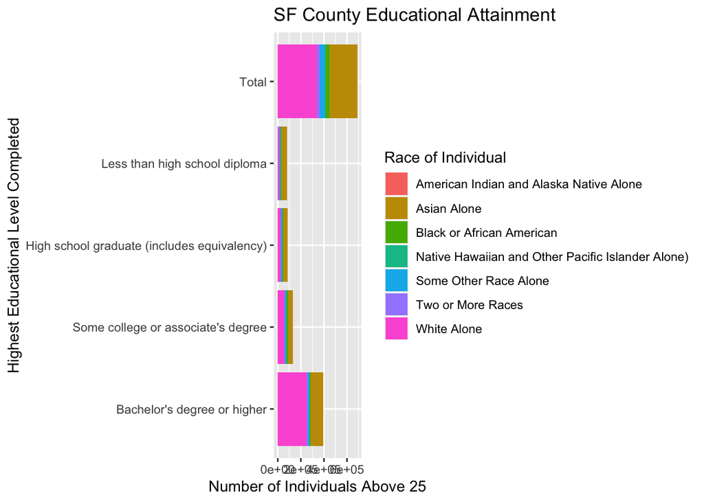

```r
SF_educational_attainment %>%
  group_by(edu_level, race) %>%
  summarize(estimate = sum(estimate)) %>%
  rbind(SF_race_total) %>%
  ggplot() +
  geom_bar(
    aes(
      x = edu_level %>% factor(levels = rev(c("Total", SF_educational_attainment$edu_level[1:4]))),
      y = estimate,
      fill = race
    ),
    stat = "identity",
    position = "stack"
  ) +
  labs(
    x = "Highest Educational Level Completed",
    y = "Number of Individuals Above 25",
    title = "SF County Educational Attainment",
    fill = "Race of Individual"
  ) +
  coord_flip()
```

The following bar chart indicates the number of people attaining a certain educational degree, split by race, in SF County. It displays that over 50% of county residents have at least a bachelor’s degree. The most common educational attainment level for white respondents, Asian respondents, and mixed-race respondents was a bachelor’s degree. The second most common degree level for Asian respondents was “little to no high school.” The most common educational attainment level for Black respondents was a college or associate’s degree. For races not included in the survey, there were fewer respondents who had completed a Bachelor’s degree.

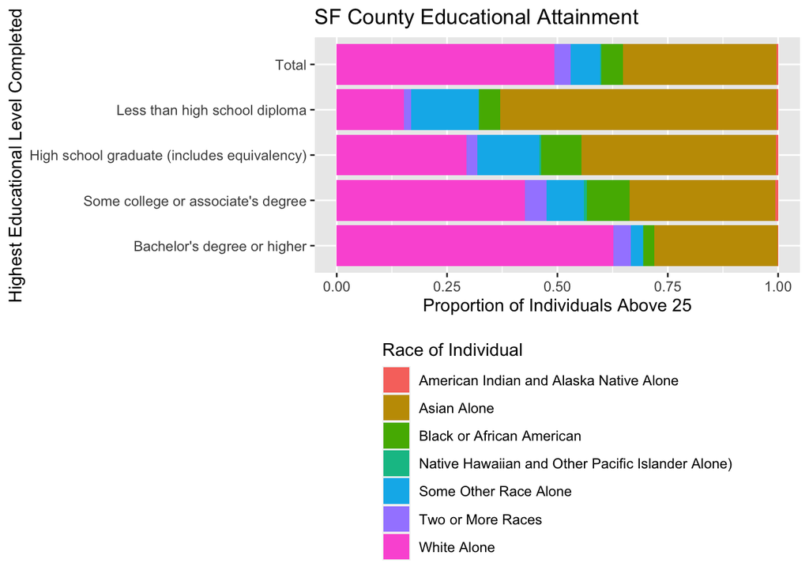

```r
SF_educational_attainment %>%
  group_by(edu_level, race) %>%
  summarize(estimate = sum(estimate)) %>%
  rbind(SF_race_total) %>%
  ggplot() +
  geom_bar(
    aes(
      x = edu_level %>% factor(levels = rev(c("Total", SF_educational_attainment$edu_level[1:4]))),
      y = estimate,
      fill = race
    ),
    stat = "identity",
    position = "fill"
  ) +
  labs(
   x = "Highest Educational Level Completed",
    y = "Proportion of Individuals Above 25",
    title = "SF County Educational Attainment",
    fill = "Race of Individual"
  ) +
  coord_flip() +
  theme(
    legend.position = "bottom",
    legend.direction = "vertical"
  )
```

The following chart demonstrates the proportion of the population by race compared to the proportion of educational attainment by race. This graphic reveals that there is disproportionate access of educational attainment based on race. White respondents tend to achieve more bachelor’s degrees proportionally than any other race. Black respondents often had at least a high school degree, but Asian and other racial identities (singular) had the highest proportions of folks without a high school diploma. This high proportion could reflect high school/secondary school educational attainment in another country before arriving to the United States. This data does suggest that race is associated with educational attainment, and it can reflect the bias of most residents of SF. Primary industries include the tech industry and other financial services, which requires a bachelor’s degree and attracts many mostly Asian and white employees. Also, the disparities within Asian respondents could be attributed to immigrant status and ethnicity, which vary greatly. This data may reveal pipeline issues in educational and job mobility in San Francisco, which cater to mostly white residents and respondents.

## Part 2: Access to Internet for K-12 Students

```r
library(tigris)
library(tidycensus)
library(sf)
census_api_key("c8aa67e4086b4b5ce3a8717f59faa9a28f611dab", install = TRUE, overwrite = TRUE)
```

```
## [1] "c8aa67e4086b4b5ce3a8717f59faa9a28f611dab"
```

```r
ca_pums_edu <- get_pums(
  variables = c(
    "PUMA",
    "NP",
    "ACCESS",
    "SCHG"
  ),
  state = "CA",
  survey = "acs1",
  recode = T
)

saveRDS(ca_pums_edu,"ca_pums_edu.rds")
```

```r
ca_pums_edu <-
  readRDS("ca_pums_edu.rds")
```

```r
ca_pumas <-
  pumas("CA", cb = T, progress_bar = F)

ca_counties <- counties("CA", cb = T, progress_bar = F)

SF_county <-
  ca_counties %>%
  filter(NAME == "San Francisco")

SF_pumas <-
  ca_pumas %>%
  st_centroid() %>%
  .[SF_county, ] %>%
  st_set_geometry(NULL) %>%
  left_join(ca_pumas %>% select(GEOID10)) %>%
  st_as_sf()
```

```r
#Filter by Grade School Students & Households by Internet Access
SF_pums_edu <-
  ca_pums_edu %>%
  filter(PUMA %in% SF_pumas$PUMACE10) %>%
  mutate(SCHG = as.numeric(SCHG)) %>%
  filter(SCHG %in% c(2:14)) %>%
  mutate(
    no_internet= ifelse(
      (ACCESS == "3"),
      PWGTP,
      0
    )
  )
```

```r
#create PUMA level leaflet graph
student_internet_access_graph <-
  SF_pums_edu %>%
  group_by(PUMA) %>%
  summarize(
    perc_no_internet =
      sum(no_internet, na.rm =T)/sum(PWGTP, na.rm = T)*100,
    total_no_internet = sum(no_internet, na.rm = T)
  ) %>%
  left_join(
    SF_pumas %>%
      select(PUMACE10),
    by = c("PUMA" = "PUMACE10")
  ) %>%
  st_as_sf()
```

```r
library(leaflet)

pums_col <- colorNumeric(
  palette = "Reds",
  domain = student_internet_access_graph$perc_no_internet
)

leaflet() %>%
  addTiles() %>%
  addPolygons(
    data = student_internet_access_graph %>% st_transform(4326),
    fillColor = ~pums_col(perc_no_internet),
    color = "white",
    opacity = 0.5,
    fillOpacity = 0.5,
    weight = 1,
    label = ~paste0(
      round(perc_no_internet),
      "% K-12 Students, No Home Internet"
    ),
    highlightOptions = highlightOptions(
      weight = 2,
      opacity = 1
    )
  ) %>%
  addLegend(
    data = student_internet_access_graph,
    pal = pums_col,
    values = ~perc_no_internet,
    title = "% of K-12 students<br>with no home Internet<br>in SF County"
  )
```

[interactive chart not shown]

```r
student_internet_access_table <-
  SF_pums_edu  %>%
  summarize(
    perc_no_internet =
      sum(no_internet, na.rm =T)/sum(PWGTP, na.rm = T)*100,
      total_no_internet = sum(no_internet, na.rm = T)
  ) %>%
  kable() %>%
  kable_styling()

student_internet_access_table
```

| perc_no_internet | total_no_internet |
| --- | --- |
| 4.904567 | 3708 |

Given the increase in technology-supplemented classrooms and distance/virtual learning, an important measure of education includes the number of K-12 students without access to the internet. We started by accessing the SCGH marker of the individual data from PUMS for SF county. Using the serial number (a marker connecting individual responses to household responses), we joined household internet access to students currently in K-12. It should be noted that this data is 1-year census information from 2019,which may not reflect 2020 conditions and predominantly, how COVID-19 has changed internet access.

The results show that about 5% (4.9%) of K-12 students don’t have access to the internet, which equates to around 3700 students. However, with distance learning, 5% of students may receive virtually no education or communication from their school. This 5% would also be significant if certain schools had much higher percentages of students without Internet access, indicating that neighborhood level access and outcomes were affected rather than individuals who presumably live near someone with Wifi. Furthermore, loss of employment, the closure of businesses and services offering Wifi, and PG&E energy shutoffs during this COVID-19 period have likely increased the number of students with little to poor access to Internet. Even households with good Wifi access may be struggling under the bandwidth of students moving back home. These factors indicate great potential for reduced educational quality and engagement based on access to Internet.

## Part 3: Educational Mobility through Migration Analysis

```r
acs_vars_2019_1yr <-
  listCensusMetadata(
    name = "2019/acs/acs1",
    type = "variables"
  )
```

```r
SF_mobility_current_19 <-
  getCensus(
    name = "acs/acs1",
    vintage = 2019,
    region = "county:075",
    regionin = "state:06",
    vars = c("group(B07009)")
  ) %>%
  select(!c(GEO_ID,state,NAME) & !ends_with(c("EA","MA","M"))) %>%
  pivot_longer(
    ends_with("E"),
    names_to = "variable",
    values_to = "estimate"
  ) %>%
  left_join(
    acs_vars_2019_1yr %>%
      select(name, label),
    by = c("variable" = "name")
  ) %>%
  select(-variable) %>%
  separate(
    label,
    into = c(NA,NA,"mobility","edu_level"),
    sep = "!!"
  ) %>%
  mutate(
    mobility = ifelse(
      mobility %in% c("Same house 1 year ago:", "Moved within same county:"),
      "Here since last year",
      "Inflow"
    )
  ) %>%
  filter(!is.na(edu_level)) %>%
  group_by(mobility, edu_level) %>%
  summarize(estimate = sum(estimate))
```

```r
SF_mobility_lastyear_19 <-
  getCensus(
    name = "acs/acs1",
    vintage = 2019,
    region = "county:075",
    regionin = "state:06",
    vars = c("group(B07409)")
  ) %>%
  select(!c(GEO_ID,state,NAME) & !ends_with(c("EA","MA","M"))) %>%
  pivot_longer(
    ends_with("E"),
    names_to = "variable",
    values_to = "estimate"
  ) %>%
  left_join(
    acs_vars_2019_1yr %>%
      select(name, label),
    by = c("variable" = "name")
  ) %>%
  select(-variable) %>%
  separate(
    label,
    into = c(NA,NA,"mobility","edu_level"),
    sep = "!!"
  ) %>%
    mutate(
      mobility = ifelse(
      mobility %in% c("Same house:", "Moved within same county:"),
      "Here since last year",
      "Outflow"
    )
  ) %>%
  filter(!is.na(edu_level)) %>%
  group_by(mobility, edu_level) %>%
  summarize(estimate = sum(estimate))
```

```r
SF_mobility_current_18 <-
  getCensus(
    name = "acs/acs1",
    vintage = 2018,
    region = "county:075",
    regionin = "state:06",
    vars = c("group(B07009)")
  ) %>%
  select(!c(GEO_ID,state,NAME) & !ends_with(c("EA","MA","M"))) %>%
  pivot_longer(
    ends_with("E"),
    names_to = "variable",
    values_to = "estimate"
  ) %>%
  left_join(
    acs_vars_2019_1yr %>%
      select(name, label),
    by = c("variable" = "name")
  ) %>%
  select(-variable) %>%
  separate(
    label,
    into = c(NA,NA,"mobility","edu_level"),
    sep = "!!"
  ) %>%
  mutate(
    mobility = "Here last year"
  ) %>%
  filter(!is.na(edu_level)) %>%
  group_by(mobility, edu_level) %>%
  summarize(estimate = sum(estimate))
```

```r
SF_flows_19 <-
  rbind(
    SF_mobility_current_18,
    SF_mobility_lastyear_19 %>%
      filter(mobility == "Outflow"),
    SF_mobility_current_19 %>%
      filter(mobility == "Inflow"),
    SF_mobility_current_19 %>%
      group_by(edu_level) %>%
      summarize(estimate = sum(estimate)) %>%
      mutate(mobility = "Here this year")
  ) %>%
  pivot_wider(
    names_from = mobility,
    values_from = estimate
  ) %>%
  mutate(
    `External net` = Inflow - Outflow,
    `Internal net` = `Here this year` - `Here last year` - `External net`,
     edu_level = edu_level %>% factor(levels = c(
       "Less than high school graduate",
       "High school graduate (includes equivalency)",
       "Some college or associate's degree",
       "Bachelor's degree",
       "Graduate or professional degree"
     ))
  ) %>%
  arrange(edu_level) %>%
  select(
    `Educational Attainment` = edu_level,
    `Internal net`,
    `External net`,
    `Here last year`,
    `Here this year`,
    Outflow,
    Inflow
  ) %>%
  kable() %>%
  kable_styling()

SF_flows_19
```

| Educational Attainment | Internal net | External net | Here last year | Here this year | Outflow | Inflow |
| --- | --- | --- | --- | --- | --- | --- |
| Less than high school graduate | 10171 | -2013 | 73381 | 81539 | 3894 | 1881 |
| High school graduate (includes equivalency) | -3363 | 792 | 85850 | 83279 | 3705 | 4497 |
| Some college or associate’s degree | 823 | -2490 | 123004 | 121337 | 7358 | 4868 |
| Bachelor’s degree | -828 | -6881 | 253594 | 245885 | 24630 | 17749 |
| Graduate or professional degree | 3938 | -1435 | 166736 | 169239 | 16487 | 15052 |

Educational mobility refers to the change between educational attainment levels, which can be affected by both emerging educational outcomes as well as population changes due to birth, death, and migration in and out of the county. This dataset indicates the change in educational attainment levels as well as migration in and out of San Francisco for the year 2019. This data does not account for outflow of folks who may have moved abroad and therefore taken the 2018 but not 2019 data. External net refer to the change due to migration in out of the county, whereas internal net refers to the changes due to births, deaths, or educational attainment changes within the data. This data captures respondents 25 and up.

From this data, we can interpret how feasible it is to increase educational attainment in a certain county, or whether the county’s employment is associated with to a certain educational attainment. For example, the number of folks without a high school degree increased by 10,000 people in the county. That could be due to the fact that this population would see few deaths, as in the course of a lifetime, many individuals could receive a degree and increase educational attainment, then pass away and be counted in a different data set. It could also be that there has been a rise in service jobs that don’t require a high school degree for employment, so more folks have stayed in the county and worked without completing a degree. However, since it is hard to filter out births and deaths as opposed to actual number of graduates, certain educational attainment data is hard to picture. For example, the internal net data where 828 people “left” a bachelor’s degree may indicate that less people are receiving bachelor’s degrees than in the past within the county. It could also refer to the death of someone older who had long before received a bachelor’s degree rather than current graduation rates.

If we assume that a higher educational attainment would result in a higher income, the external net for lower levels of attainment can provide insights regarding affordability and job opportunity. We could interpret a large negative external net for lower degree levels alongside a large positive external net value for college and professional degrees as a sign of industry change - the newer jobs may only be for high-income, highly educated individuals, potentially displacing long time residents. This data implies that many folks moved out of San Francisco across populations, except for high school graduates. Of those that moved out, those with graduate degrees were the least affected. One theory is that growing unaffordability in SF is pushing folks out of the area, and those with graduate degrees are most likely to stay and can afford to stay. Negative external flow may have risen during the COVID-19 period, as folks with remote work moved back home or elsewhere.

While educational mobility can be difficult to define, this initial description of how populations are changing in terms of educational attainment can connect to larger employment trends and evaluate educational trends. These patterns would need to be corroborated by other evidence of societal changes and trends. Such analysis could be used to improve educational policies that encourage flexible degree completion, financing schemes for higher education, and job creation across the educational spectrum.